# Analyzing a Lower Back Pain Data

A group project by Anik Burman, Soham Das & Aditya Ghosh, under the guidance of Prof. Kiranmoy Das

Last updated: 10 January 2021

Abstract

We analyze a dataset that contains the condition of the lower back pain of 310 persons (labelled Abnormal or Normal by trained physicians), collected along with some other physical spine details. Our goal is to identify which of those measurements might be important for predicting whether the pain in a person’s lower back is Abnormal or Normal, and how to predict that using various regression models. This html document created by R markdown contains the codes used in our group project.

# Loading packages and the dataset

```r
library(corrplot)
library(ppcor)
library(faraway)
library(ggplot2)
library(ggstance)
library(ggfortify)
library(gridExtra)
library(jtools)
library(broom.mixed)
library(ggpubr)
library(pROC)
library(MASS)
```

```r
setwd("/Users/adityaghosh/Desktop/RegTechProj")
Data = read.csv("spine_data.csv")
cat("no. of rows with missing values: ", sum(is.na(Data)))
```

```
## no. of rows with missing values:  0
```

```r
head(Data)
```

|  | condition | pelvic_incidence | pelvic_tilt | lumbar_lordosis_angle | sacral_slope | pelvic_radius | degree_spondylolisthesis | pelvic_slope | Direct_tilt | thoracic_slope | cervical_tilt | sacrum_angle | scoliosis_slope |
| --- | --- | --- | --- | --- | --- | --- | --- | --- | --- | --- | --- | --- | --- |
| 1 | Abnormal | 63.02782 | 22.552586 | 39.60912 | 40.47523 | 98.67292 | -0.254400 | 0.7445035 | 12.5661 | 14.5386 | 15.30468 | -28.658501 | 43.5123 |
| 2 | Abnormal | 39.05695 | 10.060991 | 25.01538 | 28.99596 | 114.40543 | 4.564259 | 0.4151857 | 12.8874 | 17.5323 | 16.78486 | -25.530607 | 16.1102 |
| 3 | Abnormal | 68.83202 | 22.218482 | 50.09219 | 46.61354 | 105.98514 | -3.530317 | 0.4748892 | 26.8343 | 17.4861 | 16.65897 | -29.031888 | 19.2221 |
| 4 | Abnormal | 69.29701 | 24.652878 | 44.31124 | 44.64413 | 101.86850 | 11.211523 | 0.3693453 | 23.5603 | 12.7074 | 11.42447 | -30.470246 | 18.8329 |
| 5 | Abnormal | 49.71286 | 9.652075 | 28.31741 | 40.06078 | 108.16872 | 7.918501 | 0.5433605 | 35.4940 | 15.9546 | 8.87237 | -16.378376 | 24.9171 |
| 6 | Abnormal | 40.25020 | 13.921907 | 25.12495 | 26.32829 | 130.32787 | 2.230652 | 0.7899929 | 29.3230 | 12.0036 | 10.40462 | -1.512209 | 9.6548 |

# Multicollinearity?

## Checking pairwise and partial correlations

```r
Predictors = data.frame(Data[,-1])
names(Predictors)
```

```
##  [1] "pelvic_incidence"         "pelvic_tilt"
##  [3] "lumbar_lordosis_angle"    "sacral_slope"
##  [5] "pelvic_radius"            "degree_spondylolisthesis"
##  [7] "pelvic_slope"             "Direct_tilt"
##  [9] "thoracic_slope"           "cervical_tilt"
## [11] "sacrum_angle"             "scoliosis_slope"
```

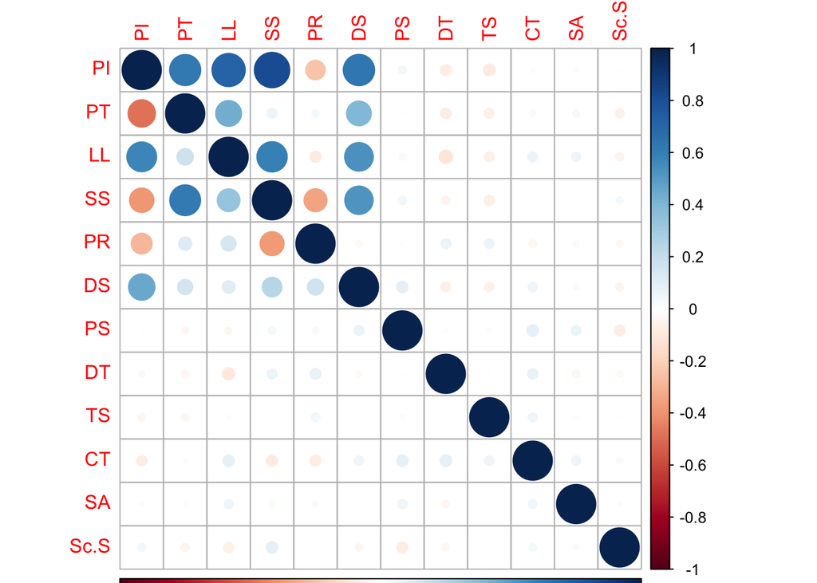

```r
R = cor(Predictors)
# pairwise correlations:
colnames(R) <- c("PI","PT","LL","SS","PR","DS","PS","DT","TS","CT","SA","Sc.S")
rownames(R) <- rep("", 12)
corrplot(R, type = "upper")

# partial correlations:
pco_r <- pcor(Predictors)$estimate
rownames(pco_r) <- colnames(R)
colnames(pco_r) = rep("", 12)
corrplot(pco_r, type = "lower", add = TRUE)
```

Pairwise correlations are shown **above** the main diagonal, and partial correlations are shown **below** the main diagonal.

## Checking multiple correlations

```r
summary(lm(pelvic_incidence ~ ., data = Predictors))$r.sq
```

```
## [1] 1
```

```r
# exploring the relation between PI, SS and PT
fit <- lm(pelvic_incidence ~ pelvic_tilt + sacral_slope, data = Predictors)
summary(fit)$r.sq
```

```
## [1] 1
```

```r
summary(fit)$adj.r.sq
```

```
## [1] 1
```

```r
summary(fit)$coef
```

```
##                  Estimate   Std. Error      t value  Pr(>|t|)
## (Intercept)  7.766518e-10 9.826641e-10 7.903533e-01 0.4299315
## pelvic_tilt  1.000000e+00 2.661832e-11 3.756811e+10 0.0000000
## sacral_slope 1.000000e+00 1.984675e-11 5.038608e+10 0.0000000
```

## Removing the redundancy

```r
dat1 = Data[, -which(names(Data) == "pelvic_incidence")]                  # only PI dropped
dat2 = Data[, -which(names(Data) == "pelvic_tilt")]                       # only PT dropped
dat3 = Data[, -which(names(Data) == "sacral_slope")]                      # only SS dropped
dat4 = Data[, -which(names(Data) %in% c("pelvic_tilt", "sacral_slope"))]  # PT and SS both dropped
dat1[,1] = ifelse(dat1[,1] == "Abnormal", 1, 0)      # transforming to binary
dat2[,1] = ifelse(dat2[,1] == "Abnormal", 1, 0)      # transforming to binary
dat3[,1] = ifelse(dat3[,1] == "Abnormal", 1, 0)      # transforming to binary
dat4[,1] = ifelse(dat4[,1] == "Abnormal", 1, 0)      # transforming to binary
```

## Variance inflation factors (after removing redundancy)

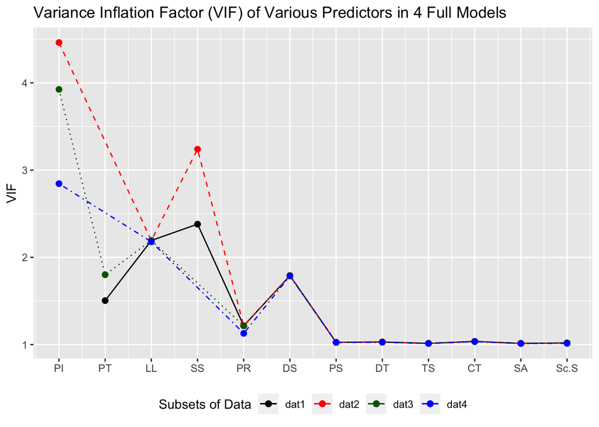

```r
vif.values1 <- vif(lm(dat1$condition ~ ., data = dat1))
vif.values2 <- vif(lm(dat2$condition ~ ., data = dat2))
vif.values3 <- vif(lm(dat3$condition ~ ., data = dat3))
vif.values4 <- vif(lm(dat4$condition ~ ., data = dat4))
vdf1 = data.frame(x = 2:12,y = vif.values1)
vdf2 = data.frame(x = c(1,3:12),y = vif.values2)
vdf3 = data.frame(x = c(1:3,5:12),y = vif.values3)
vdf4 = data.frame(x = c(1,3,5:12),y = vif.values4)
colors = c("dat1" = "black", "dat2" = "red", "dat3" = "dark green","dat4" = "blue")

vf <- ggplot(NULL) +
  geom_point(data = vdf1 ,aes(x,y,color = "dat1"),size = 2, alpha =1) +
  geom_line(data = vdf1 ,aes(x,y,color = "dat1"),linetype = 1) +
  geom_point(data = vdf2 ,aes(x,y,color = "dat2"),size = 2, alpha =1) +
  geom_line(data = vdf2 ,aes(x,y,color = "dat2"),linetype = 2) +
  geom_point(data = vdf3 ,aes(x,y,color = "dat3"),size = 2, alpha =1) +
  geom_line(data = vdf3 ,aes(x,y,color = "dat3"),linetype = 3) +
  geom_point(data = vdf4 ,aes(x,y,color = "dat4"),size = 2, alpha =1) +
  geom_line(data = vdf4 ,aes(x,y,color = "dat4"),linetype = 4) +
  scale_color_manual(values = colors) +
  labs(title = "Variance Inflation Factor (VIF) of Various Predictors in 4 Full Models",
       x =NULL,y ="VIF",color = "Subsets of Data") +
  scale_x_continuous(breaks=c(1:12),
              labels=c("PI","PT","LL","SS","PR","DS","PS","DT","TS","CT","SA","Sc.S")) +
  theme(legend.position = "bottom")
vf
```

# First attempt: multiple logisitic regression models (full models)

```r
cross_val <- function(data)
{
  df = data
  auc_vec = array(dim = 10)
  mis_vec = array(dim = 10)
  for(i in 1:10)
  {
    testid = sample(1:310,31,replace = FALSE)
    testdat = df[testid,]
    traindat = df[-testid,]
    fit = glm(condition~degree_spondylolisthesis + pelvic_radius + sacral_slope,
              data = traindat)
    testk = testdat[,1]
    testp = predict(fit,testdat)
    r <- roc(testk ~ testp)
    auc_vec[i]= auc(r)
    T = as.matrix(table(testp> 0.5, testk))
    misclass = (T[2,1] + T[2,1])/sum(T)
    mis_vec[i] = misclass
  }
  return(list("auc" =mean(auc_vec),"misclass" =mean(mis_vec)))
}


myresplot<-function(logistic.fit){
  bad.sresid = (abs(rstandard(logistic.fit)) <1e-3)
  print(rstandard(logistic.fit)[bad.sresid])
  df1 = data.frame(x = fitted(logistic.fit), y = rstandard(logistic.fit))
  df2 = data.frame(x = fitted(logistic.fit)[bad.sresid],
                   y = rstandard(logistic.fit2)[bad.sresid])
  df3 = data.frame(x = fitted(logistic.fit), y = rep(0, nrow(logistic.fit$data)))
ggplot(NULL,aes(x,y)) +
  geom_point(data = df1,aes(x,y), alpha = 0.5, size = 3) +
  geom_line(data = df3, aes(x = x, y = y), colour = "2", linetype = "dashed") +
  geom_point(data = df2, aes(x = x, y = y), colour = "red", size = 3) +
  labs( y = "Std. Residuals", x = "Fitted Values")
}

logistic.fit1 <- glm(condition ~ ., data = dat1, family = "binomial")
logistic.fit2 <- glm(condition ~ ., data = dat2, family = "binomial")
logistic.fit3 <- glm(condition ~ ., data = dat3, family = "binomial")
logistic.fit4 <- glm(condition ~ ., data = dat4, family = "binomial")
summary(logistic.fit1)
```

```
##
## Call:
## glm(formula = condition ~ ., family = "binomial", data = dat1)
##
## Deviance Residuals:
##      Min        1Q    Median        3Q       Max
## -2.71882  -0.38920   0.02686   0.38862   2.10097
##
## Coefficients:
##                           Estimate Std. Error z value Pr(>|z|)
## (Intercept)              15.181603   3.554484   4.271 1.94e-05 ***
## pelvic_tilt               0.081180   0.032373   2.508  0.01215 *
## lumbar_lordosis_angle    -0.022099   0.023306  -0.948  0.34303
## sacral_slope             -0.094716   0.031638  -2.994  0.00276 **
## pelvic_radius            -0.105369   0.023498  -4.484 7.32e-06 ***
## degree_spondylolisthesis  0.170853   0.023743   7.196 6.21e-13 ***
## pelvic_slope             -0.218792   0.687957  -0.318  0.75046
## Direct_tilt               0.013689   0.023319   0.587  0.55719
## thoracic_slope           -0.052195   0.057856  -0.902  0.36698
## cervical_tilt             0.049584   0.066419   0.747  0.45535
## sacrum_angle              0.004945   0.015924   0.311  0.75615
## scoliosis_slope          -0.009785   0.018579  -0.527  0.59843
## ---
## Signif. codes:  0 '***' 0.001 '**' 0.01 '*' 0.05 '.' 0.1 ' ' 1
##
## (Dispersion parameter for binomial family taken to be 1)
##
##     Null deviance: 389.86  on 309  degrees of freedom
## Residual deviance: 176.15  on 298  degrees of freedom
## AIC: 200.15
##
## Number of Fisher Scoring iterations: 8
```

```r
summary(logistic.fit2)
```

```
##
## Call:
## glm(formula = condition ~ ., family = "binomial", data = dat2)
##
## Deviance Residuals:
##      Min        1Q    Median        3Q       Max
## -2.71882  -0.38920   0.02686   0.38862   2.10097
##
## Coefficients:
##                           Estimate Std. Error z value Pr(>|z|)
## (Intercept)              15.181603   3.554484   4.271 1.94e-05 ***
## pelvic_incidence          0.081180   0.032373   2.508   0.0122 *
## lumbar_lordosis_angle    -0.022099   0.023306  -0.948   0.3430
## sacral_slope             -0.175896   0.040052  -4.392 1.12e-05 ***
## pelvic_radius            -0.105369   0.023498  -4.484 7.32e-06 ***
## degree_spondylolisthesis  0.170853   0.023743   7.196 6.21e-13 ***
## pelvic_slope             -0.218792   0.687957  -0.318   0.7505
## Direct_tilt               0.013689   0.023319   0.587   0.5572
## thoracic_slope           -0.052195   0.057856  -0.902   0.3670
## cervical_tilt             0.049584   0.066419   0.747   0.4553
## sacrum_angle              0.004945   0.015924   0.311   0.7562
## scoliosis_slope          -0.009785   0.018579  -0.527   0.5984
## ---
## Signif. codes:  0 '***' 0.001 '**' 0.01 '*' 0.05 '.' 0.1 ' ' 1
##
## (Dispersion parameter for binomial family taken to be 1)
##
##     Null deviance: 389.86  on 309  degrees of freedom
## Residual deviance: 176.15  on 298  degrees of freedom
## AIC: 200.15
##
## Number of Fisher Scoring iterations: 8
```

```r
summary(logistic.fit3)
```

```
##
## Call:
## glm(formula = condition ~ ., family = "binomial", data = dat3)
##
## Deviance Residuals:
##      Min        1Q    Median        3Q       Max
## -2.71882  -0.38920   0.02686   0.38862   2.10097
##
## Coefficients:
##                           Estimate Std. Error z value Pr(>|z|)
## (Intercept)              15.181603   3.554484   4.271 1.94e-05 ***
## pelvic_incidence         -0.094716   0.031638  -2.994  0.00276 **
## pelvic_tilt               0.175896   0.040052   4.392 1.12e-05 ***
## lumbar_lordosis_angle    -0.022099   0.023306  -0.948  0.34303
## pelvic_radius            -0.105369   0.023498  -4.484 7.32e-06 ***
## degree_spondylolisthesis  0.170853   0.023743   7.196 6.21e-13 ***
## pelvic_slope             -0.218792   0.687957  -0.318  0.75046
## Direct_tilt               0.013689   0.023319   0.587  0.55719
## thoracic_slope           -0.052195   0.057856  -0.902  0.36698
## cervical_tilt             0.049584   0.066419   0.747  0.45535
## sacrum_angle              0.004945   0.015924   0.311  0.75615
## scoliosis_slope          -0.009785   0.018579  -0.527  0.59843
## ---
## Signif. codes:  0 '***' 0.001 '**' 0.01 '*' 0.05 '.' 0.1 ' ' 1
##
## (Dispersion parameter for binomial family taken to be 1)
##
##     Null deviance: 389.86  on 309  degrees of freedom
## Residual deviance: 176.15  on 298  degrees of freedom
## AIC: 200.15
##
## Number of Fisher Scoring iterations: 8
```

```r
summary(logistic.fit4)
```

```
##
## Call:
## glm(formula = condition ~ ., family = "binomial", data = dat4)
##
## Deviance Residuals:
##     Min       1Q   Median       3Q      Max
## -2.6345  -0.5285   0.0574   0.3869   2.1144
##
## Coefficients:
##                           Estimate Std. Error z value Pr(>|z|)
## (Intercept)              13.961090   3.383584   4.126 3.69e-05 ***
## pelvic_incidence         -0.011136   0.023108  -0.482   0.6299
## lumbar_lordosis_angle    -0.052342   0.021419  -2.444   0.0145 *
## pelvic_radius            -0.096055   0.022446  -4.279 1.87e-05 ***
## degree_spondylolisthesis  0.149106   0.021534   6.924 4.38e-12 ***
## pelvic_slope             -0.179763   0.639950  -0.281   0.7788
## Direct_tilt               0.004905   0.021243   0.231   0.8174
## thoracic_slope           -0.039790   0.053239  -0.747   0.4548
## cervical_tilt             0.048274   0.062233   0.776   0.4379
## sacrum_angle              0.002857   0.014477   0.197   0.8435
## scoliosis_slope          -0.016884   0.016917  -0.998   0.3183
## ---
## Signif. codes:  0 '***' 0.001 '**' 0.01 '*' 0.05 '.' 0.1 ' ' 1
##
## (Dispersion parameter for binomial family taken to be 1)
##
##     Null deviance: 389.86  on 309  degrees of freedom
## Residual deviance: 200.03  on 299  degrees of freedom
## AIC: 222.03
##
## Number of Fisher Scoring iterations: 7
```

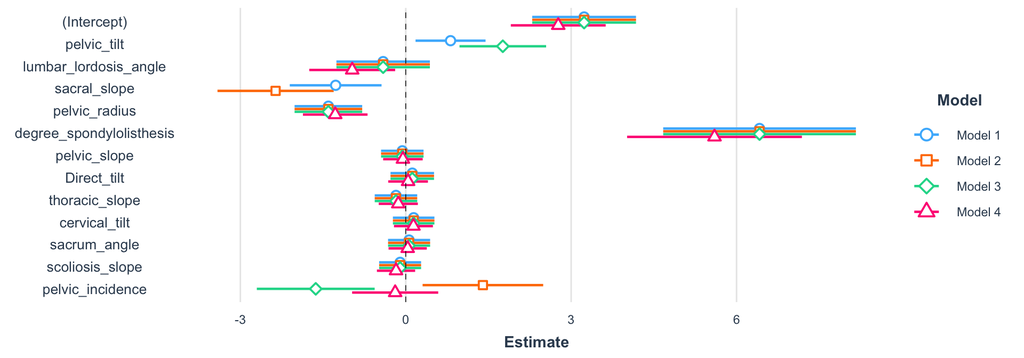

```r
glm_sum <- plot_summs(logistic.fit1, logistic.fit2, logistic.fit3, logistic.fit4, scale = TRUE,
                      omit.coefs = NULL, model.names = c("Model 1","Model 2","Model 3","Model 4"))
glm_sum
```

```r
pl1 <- myresplot(logistic.fit1) + geom_text(aes(label = "dat1", x = 1, y = 2), size = 5) +
       theme(axis.text.x = element_text(size=13), axis.text.y = element_text(size=13))+
       theme(axis.title.x =element_text(size=13)) +
       theme(axis.title.y =element_text(size=13)) # almost exact fits (if any) are printed below
```

```
##           72           76           77           96          105          116
## 8.515811e-04 1.338101e-05 5.532753e-04 5.450200e-06 7.350617e-04 2.107342e-08
##          123          142          144          193          198          203
## 8.452035e-04 6.341901e-05 2.572757e-04 1.400160e-04 1.069935e-04 3.237417e-04
##          206          207
## 7.696577e-04 5.695689e-04
```

```r
pl2 <- myresplot(logistic.fit2) + geom_text(aes(label = "dat2", x = 1, y = 2), size = 5) # almost exact fits (if any) are printed below
```

```
##           72           76           77           96          105          116
## 8.515811e-04 1.338101e-05 5.532753e-04 5.450200e-06 7.350617e-04 2.107342e-08
##          123          142          144          193          198          203
## 8.452035e-04 6.341901e-05 2.572757e-04 1.400160e-04 1.069935e-04 3.237417e-04
##          206          207
## 7.696577e-04 5.695689e-04
```

```r
pl3 <- myresplot(logistic.fit3) + geom_text(aes(label = "dat3", x = 1, y = 2), size = 5) # almost exact fits (if any) are printed below
```

```
##           72           76           77           96          105          116
## 8.515811e-04 1.338101e-05 5.532753e-04 5.450200e-06 7.350617e-04 2.107342e-08
##          123          142          144          193          198          203
## 8.452035e-04 6.341901e-05 2.572757e-04 1.400160e-04 1.069935e-04 3.237417e-04
##          206          207
## 7.696577e-04 5.695689e-04
```

```r
pl4 <- myresplot(logistic.fit4) + geom_text(aes(label = "dat4", x = 1, y = 2), size = 5) +
       theme(axis.text.x = element_text(size=13), axis.text.y = element_text(size=13)) +
       theme(axis.title.x = element_text(size=13)) +
       theme(axis.title.y = element_text(size=13)) # almost exact fits (if any) are printed below
```

```
##           76           96          116
## 3.006413e-04 1.064905e-04 2.107342e-08
```

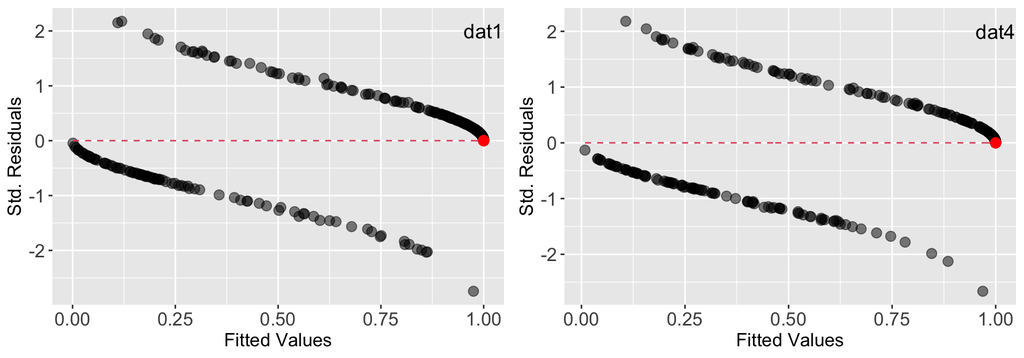

```r
grid_pl <- ggarrange(pl1, pl4)
grid_pl
```

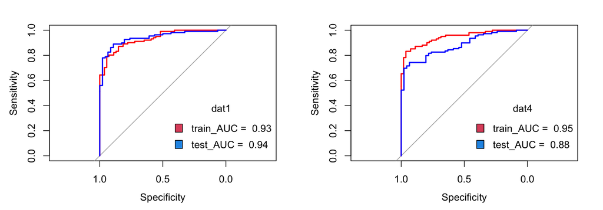

```r
myROC <- function(dat, train, logistic.fit,la){
  train.pred <- predict(logistic.fit, dat[train, ])
  train.known <- dat[train, ]$condition
  test.pred <- predict(logistic.fit, dat[-train, ])
  test.known <- dat[-train, ]$condition
  library(pROC)
  train_roc = roc(train.known ~ train.pred, plot = TRUE, col = "red")
  test_roc = roc(test.known ~ test.pred, plot = TRUE, add = TRUE, col = "blue")
  legend("bottomright", legend = c(paste("train_AUC = ", round(auc(train_roc), 2)),
                                   paste("test_AUC = ", round(auc(test_roc), 2))),
         fill = c(2, 4), bty = "n",title = la)
}

# drawing ROC curves for the fitted logistic regression on full model of dat1 and dat4

dat_1 = dat1
train = sample(nrow(dat_1), round(nrow(dat_1)/2), replace = F) # selects the training data
logistic.fit <- glm(condition ~ ., family = "binomial", data = dat_1, subset = train)

dat_4 = dat4
train = sample(nrow(dat_4), round(nrow(dat_4)/2), replace = F)
logistic.fit4 <- glm(condition ~ ., family = "binomial", data = dat_4, subset = train)
par(mfrow = 1:2,c(2,2,2,2))
myROC(dat_1, train, logistic.fit,"dat1")
myROC(dat_4, train, logistic.fit4,"dat4")
```

# (Linear or Quadratic) Discriminant Analysis

```r
Discriminant.Analysis<-function(Data){
  train = sample(nrow(Data), round(nrow(Data)/2), replace = F) # selects training data
  lda.fit = lda(condition ~ ., data = Data, subset = train)
  train.lda = predict(lda.fit, Data[train,])
  test.lda = predict(lda.fit, Data[-train,])
  l1 <- mean(train.lda$class != Data$condition[train])
  # proportions of misclassification for LDA on train data
  l2 <- mean(test.lda$class != Data$condition[-train])
  # proportions of misclassification for LDA on test data
  qda.fit = qda(condition ~ ., data = Data, subset = train)
  train.qda = predict(qda.fit, Data[train,])
  test.qda = predict(qda.fit, Data[-train,])
  q1 <- mean(train.qda$class != Data$condition[train])
  # proportions of misclassification for QDA on train data
  q2 <- mean(test.qda$class != Data$condition[-train])
  # proportions of misclassification for QDA on test data
    Mis <- matrix(c(l1, l2, q1, q2), ncol = 2, byrow = T)
    rownames(Mis) = c("LDA", "QDA"); colnames(Mis) = c("Train", "Test")
    return(Mis) # returns the proportions of misclassification
}

avg.misclass<-function(Data){
  # repeating the whole thing 20 times to get
  # a better estimate of the proportion of misclassification
  Misclassification = matrix(0, nrow = 2, ncol = 2)
  for(i in 1:20) Misclassification = Misclassification + Discriminant.Analysis(Data)
# printing the percentages of misclassification, averaged over the 20 repetitions
  return(Misclassification/20 * 100)
}

avg.misclass(dat1)
```

```
##        Train     Test
## LDA 15.61290 19.41935
## QDA 10.96774 19.96774
```

```r
avg.misclass(dat2)
```

```
##        Train     Test
## LDA 16.48387 19.45161
## QDA 12.77419 19.93548
```

```r
avg.misclass(dat3)
```

```
##        Train     Test
## LDA 15.64516 19.87097
## QDA 11.16129 20.03226
```

```r
avg.misclass(dat4)
```

```
##        Train     Test
## LDA 19.16129 24.29032
## QDA 14.61290 21.74194
```

# Finding a smaller model: Subset selection

```r
subset.select<-function(Response, Predictors, k){
  nothing <- glm(Response ~ 1 , family = binomial(logit), data = Predictors)
  full <- glm(Response ~ . , family = binomial(logit), data = Predictors)
  forwards <- step(nothing, scope = list(lower = formula(nothing), upper = formula(full)),
                   direction = "forward", k = k, trace = 0)
  backwards <- step(full, scope = list(lower = formula(nothing), upper = formula(full)),
                    direction = "backward", k = k, trace = 0)
  stepwise_n <- step(nothing, scope = list(lower=formula(nothing), upper = formula(full)),
                     direction = "both", k = k, trace = 0)
  stepwise_f <- step(full, scope = list(lower=formula(nothing), upper = formula(full)),
                     direction="both", k = k, trace = 0)
  ranks = matrix(c(forwards$rank, backwards$rank, stepwise_n$rank, stepwise_f$rank),
                 nrow = 1)
  AIC.values = matrix(c(forwards$aic, backwards$aic, stepwise_n$aic, stepwise_f$aic),
                      nrow = 1) - (2 - k) * ranks
  colnames(AIC.values) = c("forwards", "backwards", "step_nothing", "step_full")
  forwards.formula = summary(forwards)$call
  return(list(AIC.values, forwards.formula))
}

Response = ifelse(Data$condition == "Normal", 0, 1)
Predictors1 = data.frame(dat1[,-1])
Predictors2 = data.frame(dat2[,-1])
Predictors3 = data.frame(dat3[,-1])
Predictors4 = data.frame(dat4[,-1])
n = nrow(Data)
AIC.select1 = subset.select(Response, Predictors1, k = 2)
AIC.select2 = subset.select(Response, Predictors2, k = 2)
AIC.select3 = subset.select(Response, Predictors3, k = 2)
AIC.select4 = subset.select(Response, Predictors4, k = 2)
BIC.select1 = subset.select(Response, Predictors1, k = log(n))
BIC.select2 = subset.select(Response, Predictors2, k = log(n))
BIC.select3 = subset.select(Response, Predictors3, k = log(n))
BIC.select4 = subset.select(Response, Predictors4, k = log(n))

best.AICs = rbind(AIC.select1[[1]], AIC.select2[[1]], AIC.select3[[1]], AIC.select4[[1]])
best.BICs = rbind(BIC.select1[[1]], BIC.select2[[1]], BIC.select3[[1]], BIC.select4[[1]])
rownames(best.AICs) = rownames(best.BICs) = paste("dat", 1:4, sep = "")
best.AICs
```

```
##      forwards backwards step_nothing step_full
## dat1 188.9381  188.9381     188.9381  188.9381
## dat2 188.9381  188.9381     188.9381  188.9381
## dat3 190.2609  188.9381     188.9381  188.9381
## dat4 210.5473  210.5473     210.5473  210.5473
```

```r
best.BICs
```

```
##      forwards backwards step_nothing step_full
## dat1 207.2574  207.2574     207.2574  207.2574
## dat2 207.2574  207.2574     207.2574  207.2574
## dat3 212.6803  207.6209     207.6209  207.6209
## dat4 225.4936  225.4936     225.4936  225.4936
```

## Examining the best subset models chosen by AIC or BIC

```r
# Diagnostic for Best Subset Regression (for dat1 or dat2)

# best model by AIC:
# condition ~ degree_spondylolisthesis + pelvic_radius + sacral_slope + pelvic_tilt

dat = dat1
logistic.fit1 <-
  glm(condition ~ degree_spondylolisthesis + pelvic_radius + sacral_slope + pelvic_tilt,
                     family = "binomial", data = dat)
summary(logistic.fit1)
```

```
##
## Call:
## glm(formula = condition ~ degree_spondylolisthesis + pelvic_radius +
##     sacral_slope + pelvic_tilt, family = "binomial", data = dat)
##
## Deviance Residuals:
##     Min       1Q   Median       3Q      Max
## -2.7927  -0.4019   0.0319   0.3795   2.2198
##
## Coefficients:
##                          Estimate Std. Error z value Pr(>|z|)
## (Intercept)              15.45520    3.27262   4.723 2.33e-06 ***
## degree_spondylolisthesis  0.16541    0.02289   7.227 4.92e-13 ***
## pelvic_radius            -0.10893    0.02279  -4.780 1.75e-06 ***
## sacral_slope             -0.11495    0.02266  -5.072 3.94e-07 ***
## pelvic_tilt               0.06647    0.02925   2.272   0.0231 *
## ---
## Signif. codes:  0 '***' 0.001 '**' 0.01 '*' 0.05 '.' 0.1 ' ' 1
##
## (Dispersion parameter for binomial family taken to be 1)
##
##     Null deviance: 389.86  on 309  degrees of freedom
## Residual deviance: 178.94  on 305  degrees of freedom
## AIC: 188.94
##
## Number of Fisher Scoring iterations: 8
```

```r
bad.sresid1 = (abs(rstandard(logistic.fit1))<1e-3)
rstandard(logistic.fit1)[bad.sresid1]
```

```
##           76           77           96          116          142          144
## 1.862462e-05 7.176239e-04 7.883348e-06 2.107342e-08 1.085786e-04 3.183956e-04
##          193          198          203          206          207
## 2.077343e-04 5.985077e-05 3.471508e-04 6.691687e-04 7.162319e-04
```

```r
# Diagnosis for the best subset chosen by AIC:
df1 = data.frame(x = fitted(logistic.fit1),y = rstandard(logistic.fit1))
df2 = data.frame(x = fitted(logistic.fit1)[bad.sresid1],
                 y = rstandard(logistic.fit1)[bad.sresid1])
df3 = data.frame(x = fitted(logistic.fit1),y = rep(0, nrow(dat)))

aic1 <- ggplot(NULL,aes(x,y)) +
  geom_point(data = df1, aes(x,y), alpha = 0.5, size = 3) +
  geom_line(data = df3, aes(x = x, y = y), colour = "2", linetype = "dashed") +
  geom_point(data = df2, aes(x = x, y = y), colour = "red", size = 3) +
  labs(title = "Standardised Residuals vs Fitted Values (for BS.A)",
       y = "Std. Residuals", x = "Fitted Values") +
  theme(axis.text.x = element_text(size=15),axis.text.y = element_text(size=15))+
  theme(axis.title.x =element_text(size=15)) +
  theme(axis.title.y =element_text(size=15))
```

```r
# best model by BIC:
# condition ~ degree_spondylolisthesis + pelvic_radius + sacral_slope

logistic.fit2 <-
  glm(condition ~ degree_spondylolisthesis + pelvic_radius + sacral_slope,
      family = "binomial", data = dat)
summary(logistic.fit2)
```

```
##
## Call:
## glm(formula = condition ~ degree_spondylolisthesis + pelvic_radius +
##     sacral_slope, family = "binomial", data = dat)
##
## Deviance Residuals:
##      Min        1Q    Median        3Q       Max
## -2.85080  -0.46441   0.03609   0.31601   2.29474
##
## Coefficients:
##                          Estimate Std. Error z value Pr(>|z|)
## (Intercept)              18.05065    3.24413   5.564 2.64e-08 ***
## degree_spondylolisthesis  0.16491    0.02264   7.283 3.26e-13 ***
## pelvic_radius            -0.12141    0.02319  -5.236 1.64e-07 ***
## sacral_slope             -0.11707    0.02264  -5.170 2.34e-07 ***
## ---
## Signif. codes:  0 '***' 0.001 '**' 0.01 '*' 0.05 '.' 0.1 ' ' 1
##
## (Dispersion parameter for binomial family taken to be 1)
##
##     Null deviance: 389.86  on 309  degrees of freedom
## Residual deviance: 184.31  on 306  degrees of freedom
## AIC: 192.31
##
## Number of Fisher Scoring iterations: 8
```

```r
bad.sresid2 = (abs(rstandard(logistic.fit2))<1e-3)
rstandard(logistic.fit2)[bad.sresid2]
```

```
##           76           96          116          142          144          193
## 5.168100e-05 1.689374e-05 2.107342e-08 3.751764e-04 3.836917e-04 4.608627e-04
##          198          203
## 1.398770e-04 9.274480e-04
```

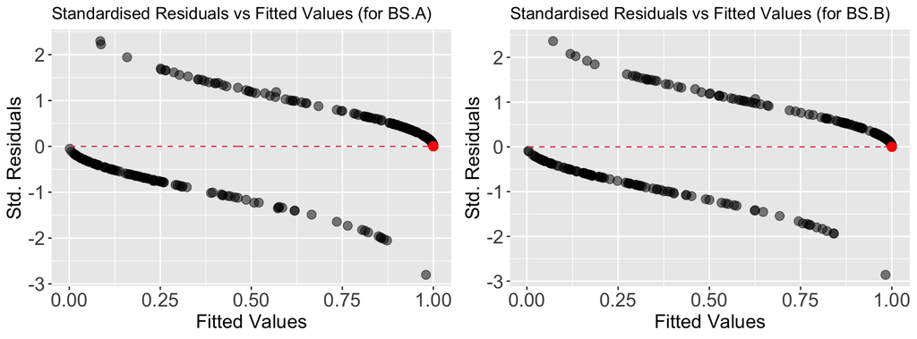

```r
# Diagnosis for the best subset chosen by BIC:

df11 = data.frame(x = fitted(logistic.fit2), y = rstandard(logistic.fit2))
df12 = data.frame(x = fitted(logistic.fit2)[bad.sresid2],
                  y = rstandard(logistic.fit2)[bad.sresid2])
df13 = data.frame(x = fitted(logistic.fit2), y = rep(0, nrow(dat)))
bic1 <- ggplot(NULL,aes(x,y)) +
  geom_point(data = df11, aes(x, y), alpha = 0.5, size = 3) +
  geom_line(data = df13, aes(x = x, y = y), colour = "2", linetype = "dashed") +
  geom_point(data = df12, aes(x = x, y = y), colour = "red", size = 3) +
  labs(title = "Standardised Residuals vs Fitted Values (for BS.B)",
       y = "Std. Residuals", x = "Fitted Values") +
  theme(axis.text.x = element_text(size=15), axis.text.y = element_text(size=15))+
  theme(axis.title.x =element_text(size=15))+
  theme(axis.title.y =element_text(size=15))

best_plot <-  ggarrange(aic1,bic1)
best_plot
```

```r
# comparing the above models using deviance (since one is the subset of the other)
ResDev1 = summary(logistic.fit1)$deviance
Resdf1 = summary(logistic.fit1)$df.residual
ResDev2 = summary(logistic.fit2)$deviance
Resdf2 = summary(logistic.fit2)$df.residual
pchisq(ResDev2 - ResDev1, Resdf2 - Resdf1, lower.tail = FALSE)
```

```
## [1] 0.02045039
```

# Removing the exact fit

## Omitting the rows having exact fit in the logisitic model

```r
Dat = Data
Dat[,1] = ifelse(Dat[,1] == "Abnormal", 1, 0)
logistic.fit = glm(condition ~ ., data = Dat, family = "binomial")
cat("\n minimum absolute standarized residual:", min(abs(rstandard(logistic.fit))))
```

```
##
##  minimum absolute standarized residual: 2.107342e-08
```

```r
epsilon = 1e-3
bad = as.vector(which(abs(rstandard(logistic.fit))<epsilon))
cat("\n no. of standardized residuals with absolute value less than", epsilon, "is:", length(bad),"\n")
```

```
##
##  no. of standardized residuals with absolute value less than 0.001 is: 14
```

```r
# Removing points that had almost the exact fit:
Data.cln = Dat[-bad,]
logistic.cln = glm(condition ~ ., data = Data.cln, family = "binomial")
cat("\n minimum absolute standarized residual for reduced data:", min(abs(rstandard(logistic.cln))))
```

```
##
##  minimum absolute standarized residual for reduced data: 0.001364085
```

```r
summary(logistic.cln)
```

```
##
## Call:
## glm(formula = condition ~ ., family = "binomial", data = Data.cln)
##
## Deviance Residuals:
##      Min        1Q    Median        3Q       Max
## -2.72592  -0.40996   0.04335   0.40636   2.19126
##
## Coefficients:
##                            Estimate Std. Error z value Pr(>|z|)
## (Intercept)               1.530e+01  3.588e+00   4.265 2.00e-05 ***
## pelvic_incidence         -2.231e+07  4.105e+07  -0.543    0.587
## pelvic_tilt               2.231e+07  4.105e+07   0.543    0.587
## lumbar_lordosis_angle    -2.124e-02  2.334e-02  -0.910    0.363
## sacral_slope              2.231e+07  4.105e+07   0.543    0.587
## pelvic_radius            -1.065e-01  2.382e-02  -4.470 7.82e-06 ***
## degree_spondylolisthesis  1.717e-01  2.386e-02   7.196 6.20e-13 ***
## pelvic_slope             -2.570e-01  6.931e-01  -0.371    0.711
## Direct_tilt               1.352e-02  2.337e-02   0.578    0.563
## thoracic_slope           -5.188e-02  5.789e-02  -0.896    0.370
## cervical_tilt             5.147e-02  6.678e-02   0.771    0.441
## sacrum_angle              4.522e-03  1.600e-02   0.283    0.777
## scoliosis_slope          -8.091e-03  1.883e-02  -0.430    0.667
## ---
## Signif. codes:  0 '***' 0.001 '**' 0.01 '*' 0.05 '.' 0.1 ' ' 1
##
## (Dispersion parameter for binomial family taken to be 1)
##
##     Null deviance: 378.64  on 295  degrees of freedom
## Residual deviance: 175.85  on 283  degrees of freedom
## AIC: 201.85
##
## Number of Fisher Scoring iterations: 7
```

The points of exact fit had the log-likelihood zero, so removing them won’t affect the residual deviances of the full models, or even the AIC values. The BIC values would decrease slightly, since $n$ is decreased now.

```r
dat1 = Data.cln[, -which(names(Data) == "pelvic_incidence")]
dat4 = Data.cln[, -which(names(Data) %in% c("pelvic_tilt", "sacral_slope"))]

full.model.1 <- glm(condition ~ ., data = dat1, family = "binomial")
full.model.4 <- glm(condition ~ ., data = dat4, family = "binomial")
summary(full.model.1)
```

```
##
## Call:
## glm(formula = condition ~ ., family = "binomial", data = dat1)
##
## Deviance Residuals:
##      Min        1Q    Median        3Q       Max
## -2.71882  -0.42579   0.04416   0.40349   2.10097
##
## Coefficients:
##                           Estimate Std. Error z value Pr(>|z|)
## (Intercept)              15.181601   3.554478   4.271 1.94e-05 ***
## pelvic_tilt               0.081180   0.032373   2.508  0.01215 *
## lumbar_lordosis_angle    -0.022099   0.023306  -0.948  0.34303
## sacral_slope             -0.094716   0.031638  -2.994  0.00276 **
## pelvic_radius            -0.105369   0.023498  -4.484 7.32e-06 ***
## degree_spondylolisthesis  0.170853   0.023743   7.196 6.21e-13 ***
## pelvic_slope             -0.218791   0.687956  -0.318  0.75046
## Direct_tilt               0.013689   0.023318   0.587  0.55719
## thoracic_slope           -0.052195   0.057856  -0.902  0.36698
## cervical_tilt             0.049584   0.066419   0.747  0.45534
## sacrum_angle              0.004945   0.015924   0.311  0.75615
## scoliosis_slope          -0.009785   0.018579  -0.527  0.59843
## ---
## Signif. codes:  0 '***' 0.001 '**' 0.01 '*' 0.05 '.' 0.1 ' ' 1
##
## (Dispersion parameter for binomial family taken to be 1)
##
##     Null deviance: 378.64  on 295  degrees of freedom
## Residual deviance: 176.15  on 284  degrees of freedom
## AIC: 200.15
##
## Number of Fisher Scoring iterations: 7
```

```r
summary(full.model.4)
```

```
##
## Call:
## glm(formula = condition ~ ., family = "binomial", data = dat4)
##
## Deviance Residuals:
##     Min       1Q   Median       3Q      Max
## -2.6345  -0.5483   0.0670   0.4027   2.1144
##
## Coefficients:
##                           Estimate Std. Error z value Pr(>|z|)
## (Intercept)              13.960897   3.383800   4.126 3.69e-05 ***
## pelvic_incidence         -0.011136   0.023109  -0.482   0.6299
## lumbar_lordosis_angle    -0.052341   0.021421  -2.443   0.0145 *
## pelvic_radius            -0.096053   0.022447  -4.279 1.88e-05 ***
## degree_spondylolisthesis  0.149100   0.021541   6.922 4.47e-12 ***
## pelvic_slope             -0.179734   0.639977  -0.281   0.7788
## Direct_tilt               0.004905   0.021244   0.231   0.8174
## thoracic_slope           -0.039790   0.053241  -0.747   0.4548
## cervical_tilt             0.048272   0.062236   0.776   0.4380
## sacrum_angle              0.002857   0.014477   0.197   0.8436
## scoliosis_slope          -0.016884   0.016918  -0.998   0.3183
## ---
## Signif. codes:  0 '***' 0.001 '**' 0.01 '*' 0.05 '.' 0.1 ' ' 1
##
## (Dispersion parameter for binomial family taken to be 1)
##
##     Null deviance: 378.64  on 295  degrees of freedom
## Residual deviance: 200.03  on 285  degrees of freedom
## AIC: 222.03
##
## Number of Fisher Scoring iterations: 7
```

Best models chosen by AIC or BIC would remain the same, let’s check their AIC or BIC values and look at the summary of the two models.

```r
dat1 = Data.cln[, -which(names(Data) == "pelvic_incidence")]                   # only PI dropped
model.BS.A <- glm(condition ~ degree_spondylolisthesis + pelvic_radius + sacral_slope + pelvic_tilt, data = dat1, family = "binomial")
model.BS.B <- glm(condition ~ degree_spondylolisthesis + pelvic_radius + sacral_slope, data = dat1, family = "binomial")
summary(model.BS.A)
```

```
##
## Call:
## glm(formula = condition ~ degree_spondylolisthesis + pelvic_radius +
##     sacral_slope + pelvic_tilt, family = "binomial", data = dat1)
##
## Deviance Residuals:
##      Min        1Q    Median        3Q       Max
## -2.79265  -0.45180   0.04729   0.40082   2.21984
##
## Coefficients:
##                          Estimate Std. Error z value Pr(>|z|)
## (Intercept)              15.45520    3.27261   4.723 2.33e-06 ***
## degree_spondylolisthesis  0.16541    0.02289   7.227 4.92e-13 ***
## pelvic_radius            -0.10893    0.02279  -4.780 1.75e-06 ***
## sacral_slope             -0.11495    0.02266  -5.072 3.94e-07 ***
## pelvic_tilt               0.06647    0.02925   2.272   0.0231 *
## ---
## Signif. codes:  0 '***' 0.001 '**' 0.01 '*' 0.05 '.' 0.1 ' ' 1
##
## (Dispersion parameter for binomial family taken to be 1)
##
##     Null deviance: 378.64  on 295  degrees of freedom
## Residual deviance: 178.94  on 291  degrees of freedom
## AIC: 188.94
##
## Number of Fisher Scoring iterations: 7
```

```r
summary(model.BS.B)
```

```
##
## Call:
## glm(formula = condition ~ degree_spondylolisthesis + pelvic_radius +
##     sacral_slope, family = "binomial", data = dat1)
##
## Deviance Residuals:
##      Min        1Q    Median        3Q       Max
## -2.85079  -0.49357   0.04411   0.41460   2.29474
##
## Coefficients:
##                          Estimate Std. Error z value Pr(>|z|)
## (Intercept)              18.05061    3.24414   5.564 2.64e-08 ***
## degree_spondylolisthesis  0.16491    0.02264   7.283 3.27e-13 ***
## pelvic_radius            -0.12141    0.02319  -5.236 1.64e-07 ***
## sacral_slope             -0.11707    0.02264  -5.170 2.34e-07 ***
## ---
## Signif. codes:  0 '***' 0.001 '**' 0.01 '*' 0.05 '.' 0.1 ' ' 1
##
## (Dispersion parameter for binomial family taken to be 1)
##
##     Null deviance: 378.64  on 295  degrees of freedom
## Residual deviance: 184.31  on 292  degrees of freedom
## AIC: 192.31
##
## Number of Fisher Scoring iterations: 7
```

Since the model BS.B is a sub-model of the model BS.A, we can compare their deviances using a chi-squared test.

```r
pchisq(model.BS.B$deviance - model.BS.A$deviance, model.BS.B$df.residual - model.BS.A$df.residual, lower.tail = F)
```

```
## [1] 0.02045072
```

# Finding a smaller model: Penalized Regression

Here we apply shrinkage methods, such as the Ridge, Lasso and Elastic net with $\alpha = 0.5$ on the reduced dataset.

```r
library(glmnet)
library(plotmo)
set.seed(999)
dat = Data.cln
X = model.matrix(condition ~ ., data = dat)
y = dat$condition
```

## Comparing ridge, lasso and enet0.5

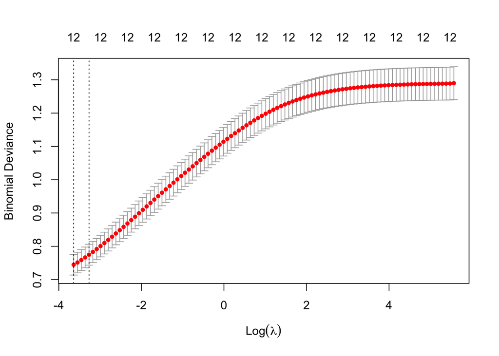

```r
require(doMC)
registerDoMC(cores = 4)
set.seed(9)

ridge.fit = glmnet(X, y, family = "binomial", alpha = 0)
cv.ridge = cv.glmnet(X, y, family = "binomial", alpha = 0, nfolds = 10)
s.ridge = cv.ridge$cvm[cv.ridge$lambda == cv.ridge$lambda.1se]

lasso.fit = glmnet(X, y, family = "binomial", alpha = 1)
cv.lasso = cv.glmnet(X, y, family = "binomial", alpha = 1, nfolds = 10)
s.lasso = cv.lasso$cvm[cv.lasso$lambda == cv.lasso$lambda.1se]

enet.fit = glmnet(X, y, family = "binomial", alpha = 0.5)
cv.enet = cv.glmnet(X, y, family = "binomial", alpha = 0.5, nfolds = 10)
s.enet = cv.enet$cvm[cv.enet$lambda == cv.enet$lambda.1se]

# CV plots:
plot(cv.ridge)
```

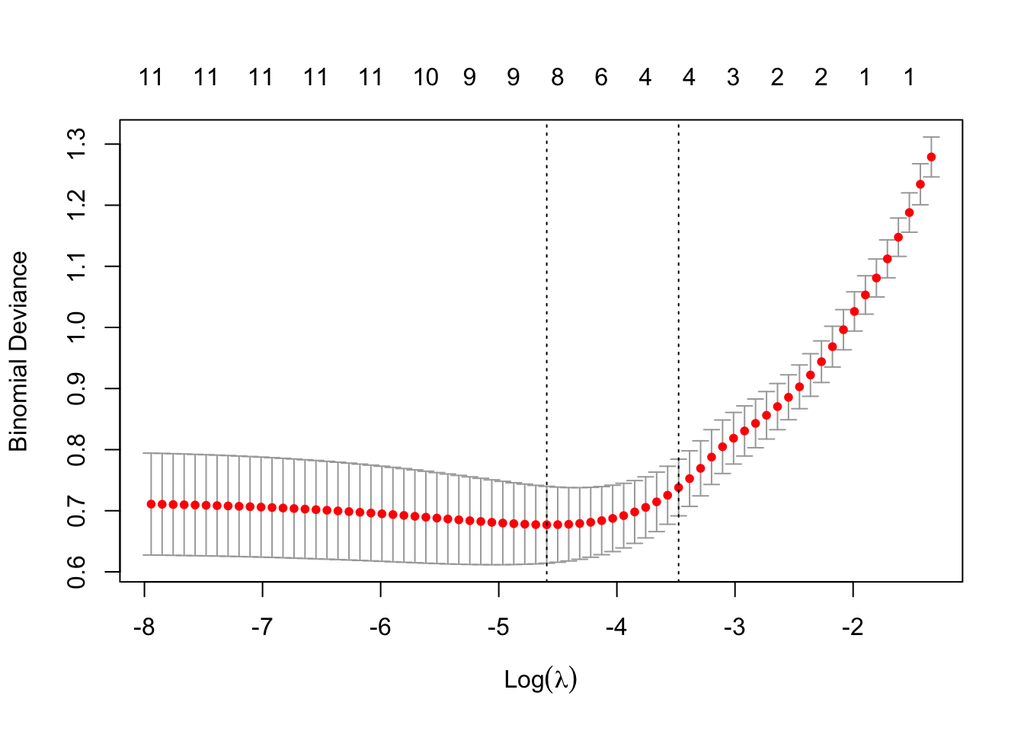

```r
plot(cv.lasso)
```

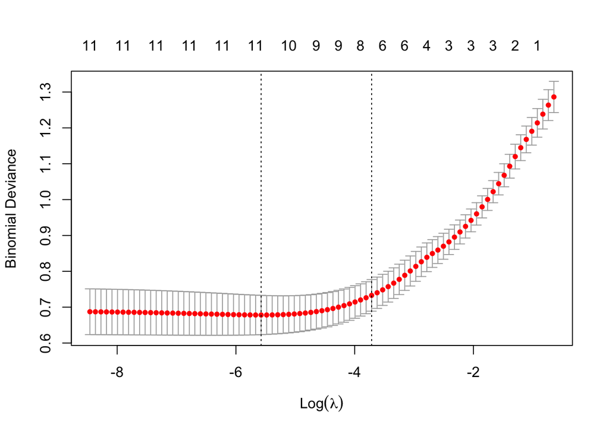

```r
plot(cv.enet)
```

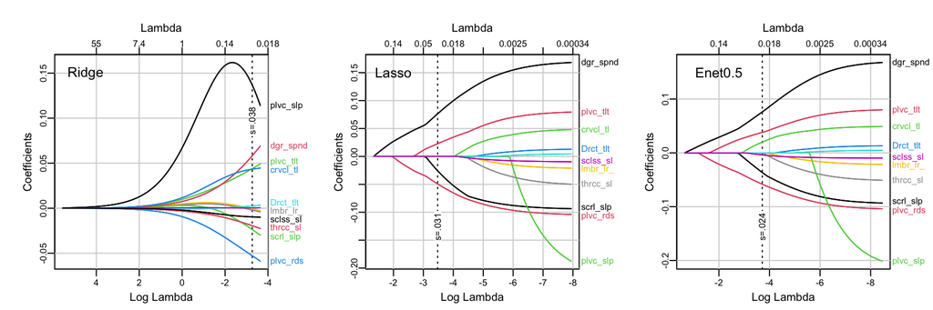

```r
par(mfrow = c(1, 3), mar = c(3, 4, 4, 1))
plot_glmnet(ridge.fit, xvar = "rlambda", col = 1:8, grid.col = "light grey", s = cv.ridge$lambda.1se)
text(x = 4.5, y = 0.15, "Ridge", cex = 1.2)
plot_glmnet(lasso.fit, xvar = "rlambda", col = 1:8, grid.col = "light grey", s = cv.lasso$lambda.1se)
text(x = -2, y = 0.15, "Lasso", cex = 1.2)
plot_glmnet(enet.fit, xvar = "rlambda", col = 1:8, grid.col = "light grey", s = cv.enet$lambda.1se)
text(x = -2, y = 0.15, "Enet0.5", cex = 1.2)
```

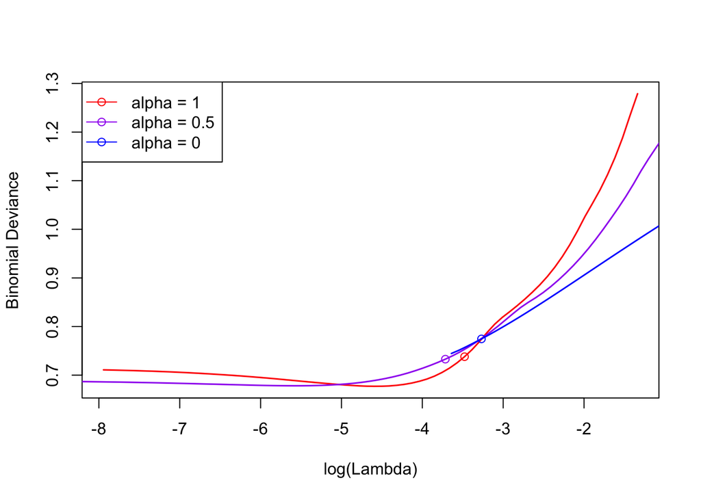

```r
plot(log(cv.lasso$lambda), cv.lasso$cvm, ty = "l", lwd = 1.5, col="red", xlab="log(Lambda)", ylab=cv.lasso$name)
points(x = log(cv.lasso$lambda.1se), y = cv.lasso$cvm[cv.lasso$lambda == cv.lasso$lambda.1se], col = "red")
lines(log(cv.enet$lambda), cv.enet$cvm, pch=19, lwd = 1.5, col="purple")
points(x = log(cv.enet$lambda.1se), y = cv.enet$cvm[cv.enet$lambda == cv.enet$lambda.1se], col = "purple")
lines(log(cv.ridge$lambda), cv.ridge$cvm, pch=19, lwd = 1.5, col="blue")
points(x = log(cv.ridge$lambda.1se), y = cv.ridge$cvm[cv.ridge$lambda == cv.ridge$lambda.1se], col = "blue")
legend("topleft", legend=c("alpha = 1","alpha = 0.5","alpha = 0"), lwd = 1, pch = 1, col=c("red","purple","blue"))
```

```r
Coefs = cbind(coef(cv.ridge, s = cv.ridge$lambda.1se), coef(cv.lasso, s = cv.lasso$lambda.1se), coef(cv.enet, s = cv.enet$lambda.1se))
colnames(Coefs) = c("ridge", "lasso", "enet0.5")
cat("\nComparing using deviances\n")
```

```
##
## Comparing using deviances
```

```r
print(Coefs[-2,])
```

```
## 13 x 3 sparse Matrix of class "dgCMatrix"
##                                  ridge       lasso      enet0.5
## (Intercept)               6.3673826039  6.16822611  7.301750871
## pelvic_incidence         -0.0005810796  .           .
## pelvic_tilt               0.0439041348  0.02279376  0.038122835
## lumbar_lordosis_angle    -0.0020494803  .           .
## sacral_slope             -0.0237328119 -0.02572944 -0.036491302
## pelvic_radius            -0.0527990084 -0.04928050 -0.058282331
## degree_spondylolisthesis  0.0583211383  0.07638529  0.076134263
## pelvic_slope              0.1367378619  .           .
## Direct_tilt               0.0025039767  .           .
## thoracic_slope           -0.0194698750  .           .
## cervical_tilt             0.0434022184  .           0.019873671
## sacrum_angle              0.0003918231  .           .
## scoliosis_slope          -0.0096550480  .          -0.003863038
```

```r
print(cbind(s.ridge, s.lasso, s.enet))
```

```
##        s.ridge   s.lasso    s.enet
## [1,] 0.7746114 0.7380103 0.7329087
```

Note that we get more or less similar results from Lasso and elastic net, which are better than the results from ridge. And as usual, lasso chooses the smallest number of predictors to achieve that.

Next we compare them (Ridge, Lasso, Enet0.5) on the basis of misclassification error rates and auc (area under ROC curve) values.

```r
compare.penreg<-function(type.meas){
  ridge.fit = glmnet(X, y, family = "binomial", alpha = 0)
  cv.ridge = cv.glmnet(X, y, family = "binomial", alpha = 0, nfolds = 10, type.measure = type.meas)
  s.ridge = cv.ridge$cvm[cv.ridge$lambda == cv.ridge$lambda.1se]
  lasso.fit = glmnet(X, y, family = "binomial", alpha = 1)
  cv.lasso = cv.glmnet(X, y, family = "binomial", alpha = 1, nfolds = 10, type.measure =  type.meas)
  s.lasso = cv.lasso$cvm[cv.lasso$lambda == cv.lasso$lambda.1se]
  enet.fit = glmnet(X, y, family = "binomial", alpha = 0.5)
  cv.enet = cv.glmnet(X, y, family = "binomial", alpha = 0.5, nfolds = 10, type.measure =  type.meas)
  s.enet = cv.enet$cvm[cv.enet$lambda == cv.enet$lambda.1se]

  Coefs = cbind(coef(cv.ridge, s = cv.ridge$lambda.1se),
                coef(cv.lasso, s = cv.lasso$lambda.1se),
                coef(cv.enet, s = cv.enet$lambda.1se))
  colnames(Coefs) = c("ridge", "lasso","enet0.5")
  print(Coefs[-2,])
  print(cbind(s.ridge, s.lasso, s.enet))

  plot(log(cv.lasso$lambda), cv.lasso$cvm, ty = "l", lwd = 1.5, col="red", xlab="log(Lambda)", ylab=cv.lasso$name)
  points(x = log(cv.lasso$lambda.1se), y = cv.lasso$cvm[cv.lasso$lambda == cv.lasso$lambda.1se], col = "red")
  lines(log(cv.enet$lambda), cv.enet$cvm, pch=19, lwd = 1.5, col="purple")
  points(x = log(cv.enet$lambda.1se), y = cv.enet$cvm[cv.enet$lambda == cv.enet$lambda.1se], col = "purple")
  lines(log(cv.ridge$lambda), cv.ridge$cvm, pch=19, lwd = 1.5, col="blue")
  points(x = log(cv.ridge$lambda.1se), y = cv.ridge$cvm[cv.ridge$lambda == cv.ridge$lambda.1se], col = "blue")
  if(type.meas == "auc")
    legend("bottomleft", legend=c("alpha = 1","alpha = 0.5","alpha = 0"), lwd = 1, pch = 1, col=c("red","purple","blue"))
  if(type.meas != "auc")
  legend("topleft", legend=c("alpha = 1","alpha = 0.5","alpha = 0"), lwd = 1, pch = 1, col=c("red","purple","blue"))
}
set.seed(9)
cat("\nComparing using Misclassification rate\n")
```

```
##
## Comparing using Misclassification rate
```

```r
compare.penreg("class")
```

```
## 13 x 3 sparse Matrix of class "dgCMatrix"
##                                  ridge       lasso      enet0.5
## (Intercept)               5.6190229143  7.14946244  3.989739696
## pelvic_incidence          0.0009093422  .           .
## pelvic_tilt               0.0401353579  0.02706383  0.024646984
## lumbar_lordosis_angle    -0.0005560375  .           .
## sacral_slope             -0.0192705254 -0.03594007 -0.001272806
## pelvic_radius            -0.0482848273 -0.05529921 -0.036837152
## degree_spondylolisthesis  0.0508642828  0.08501731  0.045542451
## pelvic_slope              0.1493390366  .           .
## Direct_tilt               0.0019643261  .           .
## thoracic_slope           -0.0172377888  .           .
## cervical_tilt             0.0421632541  .           .
## sacrum_angle              0.0003464032  .           .
## scoliosis_slope          -0.0093306402  .           .
##        s.ridge   s.lasso    s.enet
## [1,] 0.1689189 0.1621622 0.1858108
```

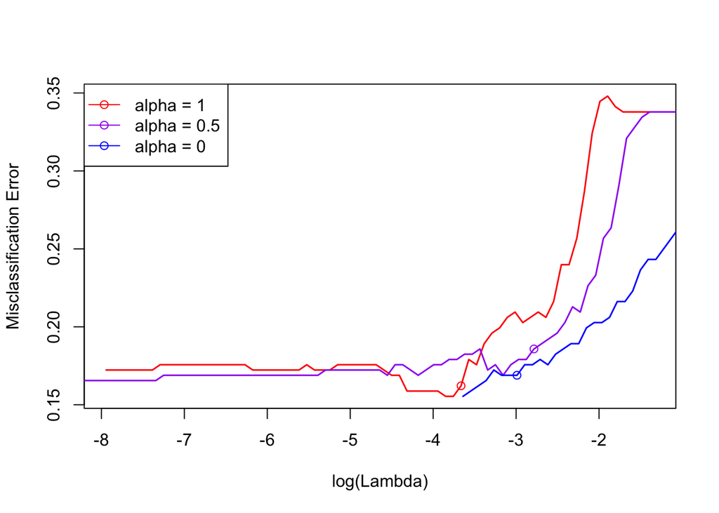

```r
cat("\nComparing using Area under ROC curve\n")
```

```
##
## Comparing using Area under ROC curve
```

```r
compare.penreg("auc")
```

```
## 13 x 3 sparse Matrix of class "dgCMatrix"
##                                  ridge       lasso       enet0.5
## (Intercept)               4.1956888074  7.61347813  5.3628784398
## pelvic_incidence          0.0035442395  .           .
## pelvic_tilt               0.0330884257  0.02915501  0.0303230862
## lumbar_lordosis_angle     0.0020421651  .           .
## sacral_slope             -0.0111422282 -0.04069740 -0.0158214417
## pelvic_radius            -0.0392892048 -0.05817769 -0.0459000140
## degree_spondylolisthesis  0.0377001327  0.08920712  0.0573916140
## pelvic_slope              0.1615349985  .           .
## Direct_tilt               0.0009675156  .           .
## thoracic_slope           -0.0131746662  .           .
## cervical_tilt             0.0384138711  .           0.0071486233
## sacrum_angle              0.0003906509  .           .
## scoliosis_slope          -0.0083296748  .          -0.0003982483
##        s.ridge   s.lasso    s.enet
## [1,] 0.8912848 0.9219499 0.9133817
```

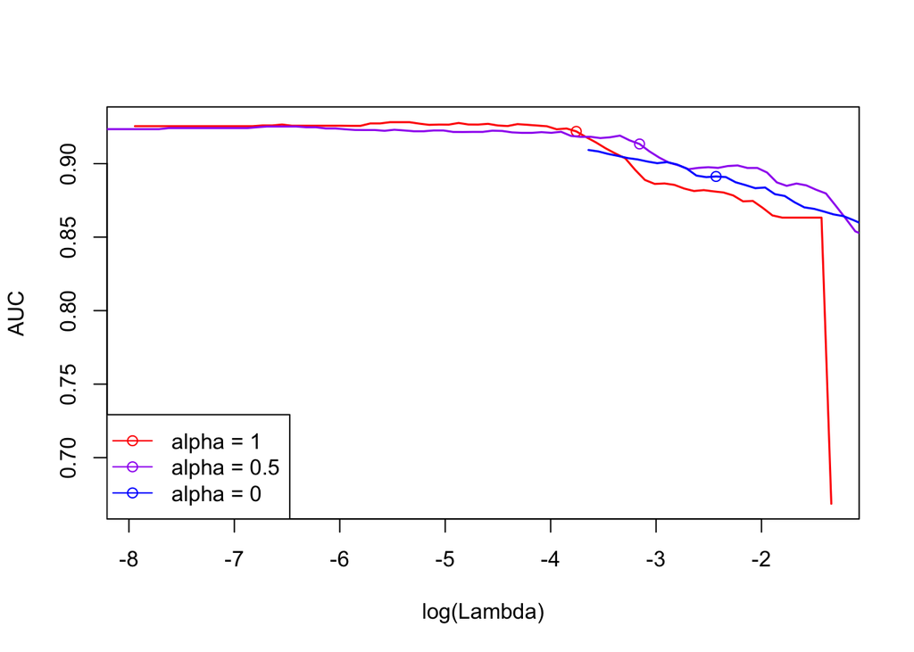

We can see the Lasso outperforms the other two. Let’s proceed with Lasso then.

## Different Type Measures for Lasso

```r
lasso.dev = cv.glmnet(X, y, family = "binomial", alpha = 1, nfolds = 10, type.measure =  "deviance")
best.dev = lasso.dev$cvm[lasso.dev$lambda == lasso.dev$lambda.1se]
lasso.class = cv.glmnet(X, y, family = "binomial", alpha = 1, nfolds = 10, type.measure =  "class")
best.class = lasso.class$cvm[lasso.class$lambda == lasso.class$lambda.1se]
lasso.auc = cv.glmnet(X, y, family = "binomial", alpha = 1, nfolds = 10, type.measure =  "auc")
best.auc = lasso.auc$cvm[lasso.auc$lambda == lasso.auc$lambda.1se]

Coefs.lasso = cbind(coef(lasso.dev, s = lasso.dev$lambda.1se), coef(lasso.class, s = lasso.class$lambda.1se), coef(lasso.auc, s = lasso.auc$lambda.1se))[-2,]
colnames(Coefs.lasso) = c("Deviance", "Class", "AUC")
print(Coefs.lasso)
```

```
## 13 x 3 sparse Matrix of class "dgCMatrix"
##                             Deviance       Class         AUC
## (Intercept)               7.61347813  7.14946244  5.65003710
## pelvic_incidence          .           .           .
## pelvic_tilt               0.02915501  0.02706383  0.02063578
## lumbar_lordosis_angle     .           .           .
## sacral_slope             -0.04069740 -0.03594007 -0.02026315
## pelvic_radius            -0.05817769 -0.05529921 -0.04613941
## degree_spondylolisthesis  0.08920712  0.08501731  0.07197317
## pelvic_slope              .           .           .
## Direct_tilt               .           .           .
## thoracic_slope            .           .           .
## cervical_tilt             .           .           .
## sacrum_angle              .           .           .
## scoliosis_slope           .           .           .
```

```r
print(cbind(best.dev, best.class, best.auc))
```

```
##       best.dev best.class  best.auc
## [1,] 0.7088138  0.1689189 0.9163829
```

# Principal Component Regression (PCR)

```r
library(stats)
pca.fit <- prcomp(Data[,-1])
summary(pca.fit)
```

```
## Importance of components:
##                            PC1     PC2      PC3      PC4      PC5      PC6
## Standard deviation     42.2123 18.5978 13.85700 12.15378 10.51872 10.25482
## Proportion of Variance  0.6224  0.1208  0.06707  0.05159  0.03865  0.03673
## Cumulative Proportion   0.6224  0.7432  0.81024  0.86184  0.90048  0.93721
##                            PC7     PC8     PC9    PC10    PC11      PC12
## Standard deviation     9.47813 8.38295 3.39480 2.83757 0.28211 2.657e-09
## Proportion of Variance 0.03138 0.02454 0.00403 0.00281 0.00003 0.000e+00
## Cumulative Proportion  0.96859 0.99313 0.99716 0.99997 1.00000 1.000e+00
```

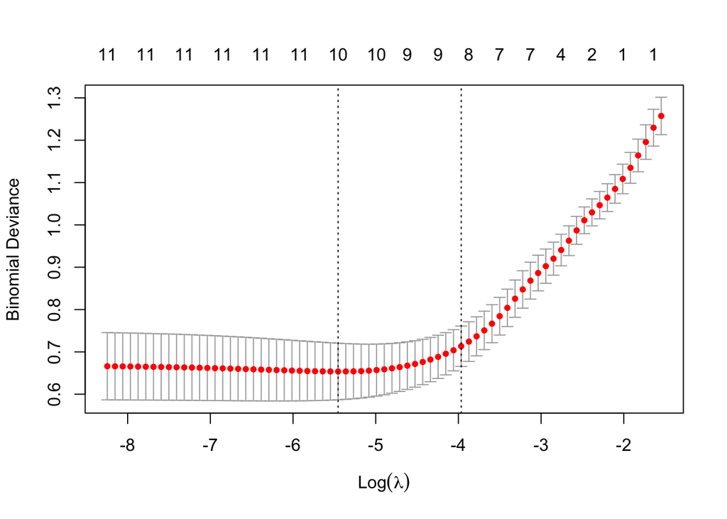

```r
X = as.matrix(Data[,-1]) %*% as.matrix(pca.fit$rotation)[,-12]
y = Data[,1]
set.seed(999)

pc.lasso.dev = cv.glmnet(X, y, family = "binomial", alpha = 1, nfolds = 10)
pc.lasso.class = cv.glmnet(X, y, family = "binomial", type.measure = "class", alpha = 1, nfolds = 10)
pc.lasso.auc = cv.glmnet(X, y, family = "binomial", type.measure = "auc", alpha = 1, nfolds = 10)

# note that many non-zero param.s are needed here
plot(pc.lasso.dev)
```

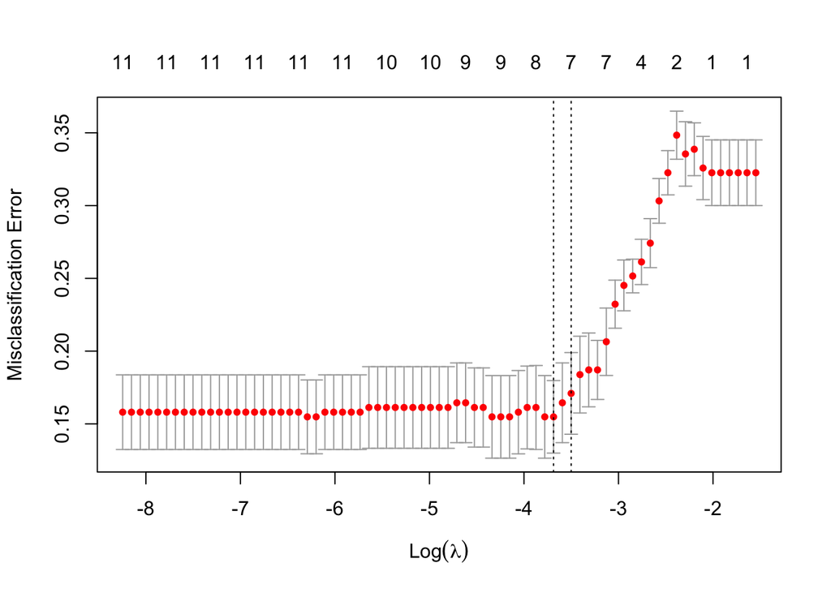

```r
plot(pc.lasso.class)
```

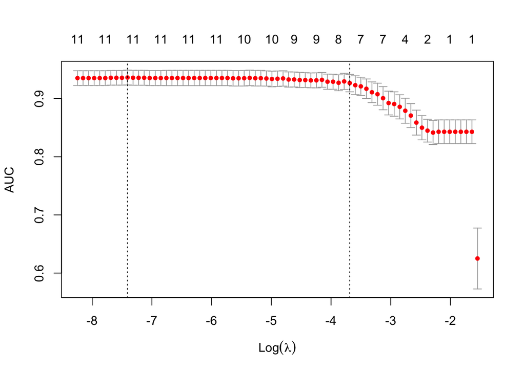

```r
plot(pc.lasso.auc)
```

```r
Coefs = cbind(coef(pc.lasso.dev, s = pc.lasso.dev$lambda.1se), coef(pc.lasso.class, s = pc.lasso.class$lambda.1se),
coef(pc.lasso.auc, s = pc.lasso.auc$lambda.1se))
colnames(Coefs) = c("Deviance", "Class", "AUC")
print(Coefs)
```

```
## 12 x 3 sparse Matrix of class "dgCMatrix"
##                 Deviance       Class         AUC
## (Intercept) -7.676627491 -5.69200487 -6.49797946
## PC1          0.062275325  0.04625427  0.05261952
## PC2          0.031256934  0.01507333  0.02183674
## PC3         -0.032218587 -0.02402772 -0.02750437
## PC4          0.001630364  .           .
## PC5          0.046884765  0.03530601  0.04007827
## PC6         -0.029689542 -0.01502336 -0.02099439
## PC7          0.047658807  0.03655307  0.04106245
## PC8          0.023143154  0.01312764  0.01730894
## PC9          .            .           .
## PC10         .            .           .
## PC11         .            .           .
```